# Visualizing Genomics Data

Rockefeller University, Bioinformatics Resource Centre

http://rockefelleruniversity.github.io/RU_VisualizingGenomicsData/

## The Course

- The Course.
- Visualising high-throughput data.
- Plotting ChIPseq data.
- Plotting Motifs occurrence

## Reminder of data types in Bioconductor

We will also encounter and make use of many data structures and data types which we have seen throughout our courses on HTS data. You can revisit this material to refresh on HTS data analysis in Bioconductor and R below.

- [Bioconductor](https://rockefelleruniversity.github.io/Bioconductor_Introduction/).
- [Genomic Intervals](https://rockefelleruniversity.github.io/Bioconductor_Introduction/r_course/presentations/slides/GenomicIntervals_In_Bioconductor.html)
- [Genomic Scores](https://rockefelleruniversity.github.io/Bioconductor_Introduction/r_course/presentations/slides/GenomicScores_In_Bioconductor.html)
- [Sequences](https://rockefelleruniversity.github.io/Bioconductor_Introduction/r_course/presentations/slides/SequencesInBioconductor.html)
- [Gene Models](https://rockefelleruniversity.github.io/Bioconductor_Introduction/r_course/presentations/slides/GenomicFeatures_In_Bioconductor.html)
- [Alignments](https://rockefelleruniversity.github.io/Bioconductor_Introduction/r_course/presentations/slides/AlignedDataInBioconductor.html).
- [ChIP-seq](http://rockefelleruniversity.github.io/RU_ChIPseq/).
- [ATAC-seq](http://rockefelleruniversity.github.io/RU_ATACseq/).
- [RNA-seq](http://rockefelleruniversity.github.io/RU_RNAseq/).

## Materials. - Presentations, source code and practicals.

Once the zip file in unarchived. All presentations as HTML slides and pages, their R code and HTML practical sheets will be available in the directories underneath.

- **viz_course/presentations/Slides/** Presentations as an HTML slide show.
- **viz_course/presentations/exercises/** Some tasks/examples to work through.

## Set the Working directory

Before running any of the code in the practicals or slides we need to set the working directory to the folder we unarchived.

You may navigate to the unarchived VisualisingGenomicsData folder in the Rstudio menu

**Session -> Set Working Directory -> Choose Directory**

or in the console.

```r
setwd("/PathToMyDownload/VisualizingGenomicsData/viz_course/presentations/Slides")
# e.g. setwd("~/Downloads/VisualizingGenomicsData/viz_course/presentations/Slides")
```

## Vizualising high dimensional Biological data.

With many high throughput sequencing experiments we are able to gain a genome wide view of our assays (in RNA-seq we measure every gene’s expression, in ChIP-seq we identify all events for a user-defined transcription factor/mark, in ATAC-seq we evaluate all open/accessible regions in the genome.)

[figure not shown]

## Vizualising high dimensional Biological data.

In this session will review a few approachs to visualising epigenetics data.

There are many alternate packages for visualising epigenetic data in Bioconductor (soGGi,heatmaps and enrichmentmap packages) and in R (ngsPlot).

Useful software outside R include Homer and Deeptools.

## CTCF ChIP-seq

Now we can produce our non-redundant set of peaks and score each of the peaks by their occurrence in our Mel and Ch12 samples.

```r
allPeaksSet_nR <- reduce(unlist(macsPeaks_GRL))
overlap <- list()
for(i in 1:length(macsPeaks_GRL)){
  overlap[[i]] <- allPeaksSet_nR %over% macsPeaks_GRL[[i]]
}
overlapMatrix <- do.call(cbind,overlap)
colnames(overlapMatrix) <- names(macsPeaks_GRL)
mcols(allPeaksSet_nR) <- overlapMatrix
allPeaksSet_nR[1,]
```

```
## GRanges object with 1 range and 4 metadata columns:
##       seqnames             ranges strand |    Ch12_1    Ch12_2     Mel_1
##          <Rle>          <IRanges>  <Rle> | <logical> <logical> <logical>
##   [1]     chr1 [3012656, 3012773]      * |      TRUE      TRUE     FALSE
##           Mel_2
##       <logical>
##   [1]     FALSE
##   -------
##   seqinfo: 21 sequences from an unspecified genome; no seqlengths
```

# Defining a consensus, non-redundant set.

We can count the number of reads overlapping our peaks using the **summarizeOverlaps** function and a BamFileList of our BAMs to count.

```r
library(Rsamtools)
library(GenomicAlignments)

bams <- c("~/Projects/Results/chipseq/testRun/BAMs/Sorted_CTCF_Ch12_1.bam",
          "~/Projects/Results/chipseq/testRun/BAMs/Sorted_CTCF_Ch12_2.bam",
          "~/Projects/Results/chipseq/testRun/BAMs/Sorted_CTCF_Mel_1.bam",
          "~/Projects/Results/chipseq/testRun/BAMs/Sorted_CTCF_Mel_2.bam")
bamFL <- BamFileList(bams,yieldSize = 5000000)
myCTCFCounts <- summarizeOverlaps(HC_Peaks,
                              reads = bamFL,
                              ignore.strand = TRUE)
colData(myCTCFCounts)$Group <- c("Ch12","Ch12","Mel","Mel")
```

# Defining a consensus, non-redundant set.

As well as to give us some normalised,transformed data for visualisation using **rlog**.

```r
CTCFrlog <- rlog(deseqCTCF)
CTCFrlog
```

# Defining a consensus, non-redundant set.

With our newly created rlog transformed CTCF signal data we can create similar visualisation as we have for RNA-seq.

First we can create our measures of sample distances.

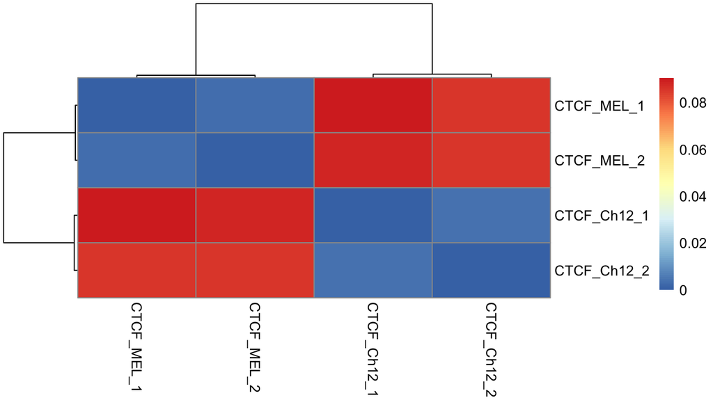

```r
pheatmap(sampleDistMatrix,
         clustering_distance_rows = sampleDists,
         clustering_distance_cols = sampleDists)
```

# Defining a consensus, non-redundant set.

We can rerun using all sites to see some additional variance in PC2.

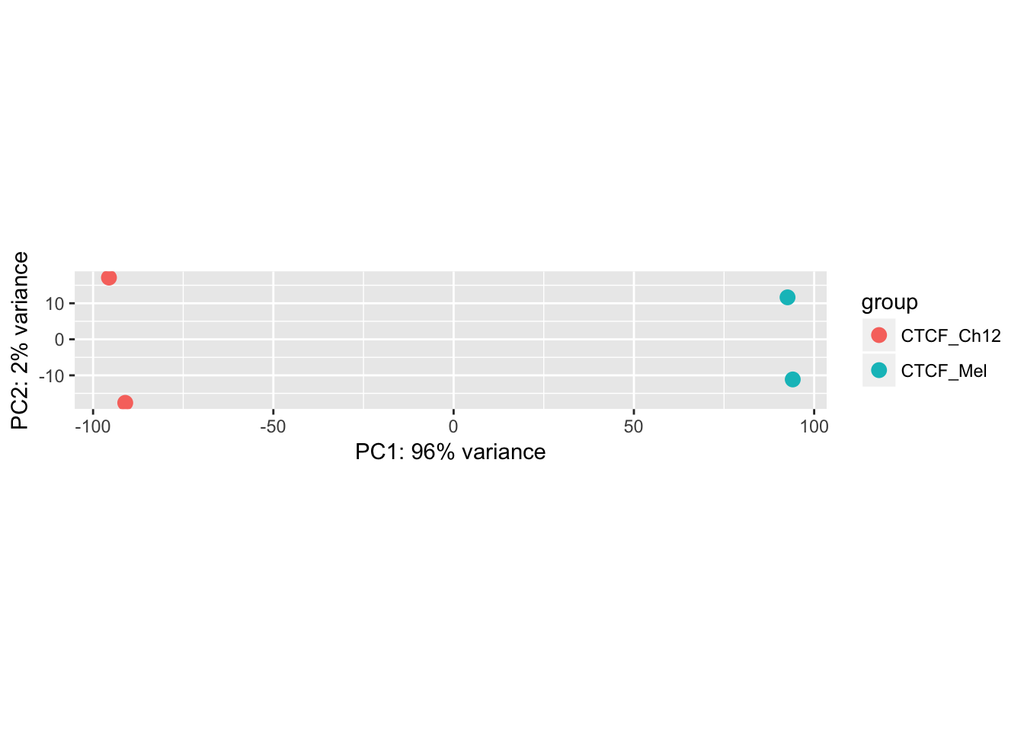

```r
plotPCA(CTCFrlog,intgroup="Group",
                  ntop=nrow(CTCFrlog))
```

# Defining a consensus, non-redundant set.

Here we add fragment length information.

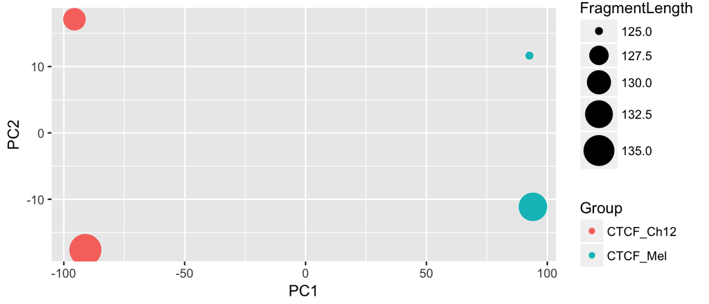

```r
myData$FragmentLength <- c(129,136,133,125)
library(ggplot2)
ggplot(myData,aes(x=PC1,y=PC2,
                  colour=Group,size=FragmentLength))+
  geom_point()+
  scale_size_continuous(range=c(2,10))
```

# Defining a consensus, non-redundant set.

We can see from the IGV that these top sites are Mel cell-line specific CTCF peaks.

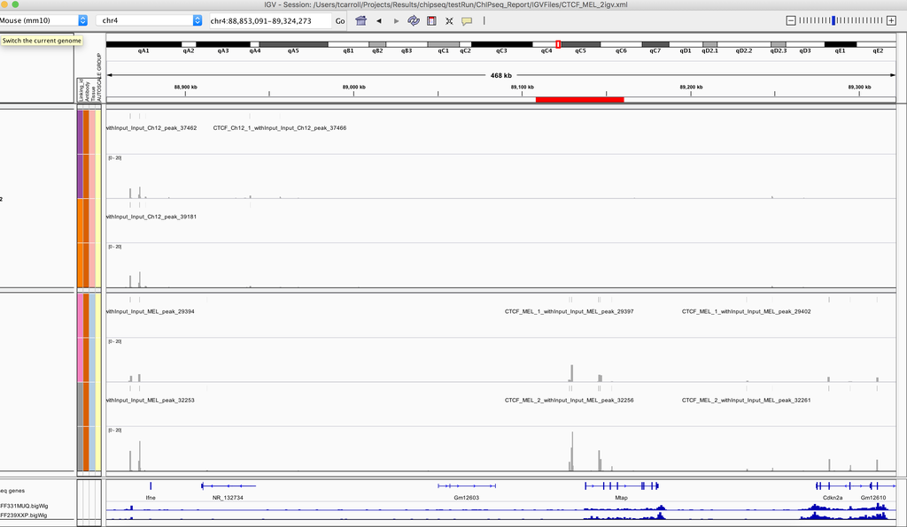

# soGGi

The soGGi package contains a set of tools to profile high-throughput signalling data and motif occurrence over a set of genomic locations.

We have used this earlier to produce some plots of our ATAC-seq signal split by fragment length over TSS regions and our cut-site footprints around CTCF motifs.

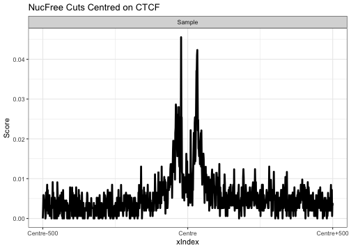

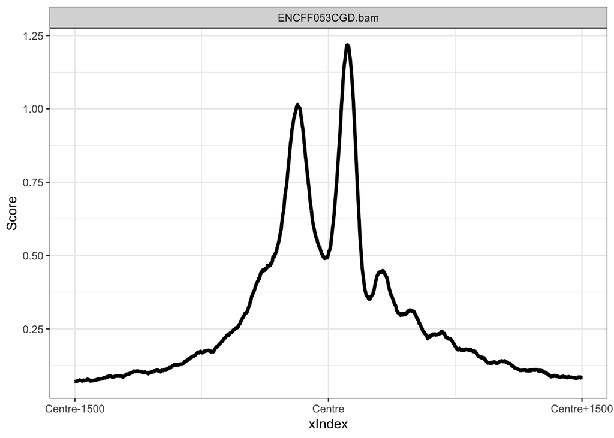

We will use the development version of soGGi package [available from Github](https://github.com/ThomasCarroll/soGGi) to take advantage of the latest features.

```r
#library(devtools)
#install_github("ThomasCarroll/soGGi")
library(soGGi)
```

# soGGi

We also add some information on CTCF site signal strength.

```r
grPs <- quantile(CTCF_Ch12MinusMel$baseMean,c(0.33,0.66))
high <-  names(CTCF_Ch12MinusMel)[CTCF_Ch12MinusMel$baseMean > grPs[2]]
low <-  names(CTCF_Ch12MinusMel)[CTCF_Ch12MinusMel$baseMean < grPs[2]]

Strength  <- ifelse(names(CTCF_Ch12MinusMel) %in% high,"high",
             ifelse(names(CTCF_Ch12MinusMel) %in% low,"low",
                    "")
             )
CTCF_Ch12MinusMel$Strength <- Strength
```

# soGGi

We can use the **regionPlot()** function with our normalised bigWig of CTCF signal by setting **format** parameter to **bigwig**. Additionally we set the plot area width with the **distanceAround** parameter.

```r
rownames(CTCF_Ch12MinusMel) <- NULL

CTCFbigWig <- "../../Data/Sorted_CTCF_Ch12_1Normalised.bw"
CTCF_ch12 <- regionPlot(CTCFbigWig,
                        testRanges = CTCF_Ch12MinusMel,
                        style = "point",
                        format = "bigwig",
                        distanceAround = 1500)
```

# soGGi

As with our other packages, **soGGi** returns a **ggplot** object which can be further customised.

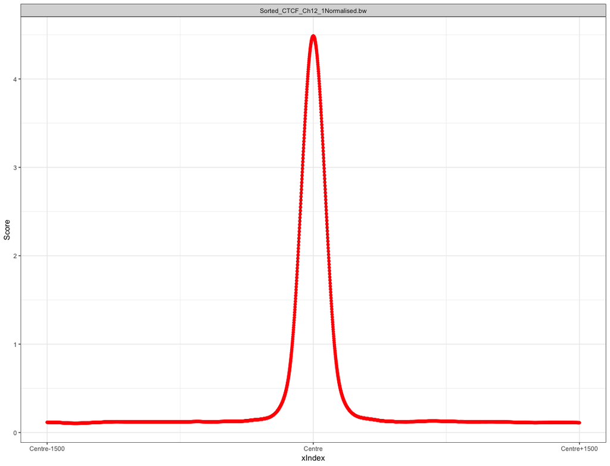

```r
p+theme_bw()+
  geom_point(colour="red")
```

# soGGi

Additional we can supply groups to the **gts** argument as a list of sets of IDS/names to create groups from.

By default the names are matched against the rownames of our **ChIPprofile** object.

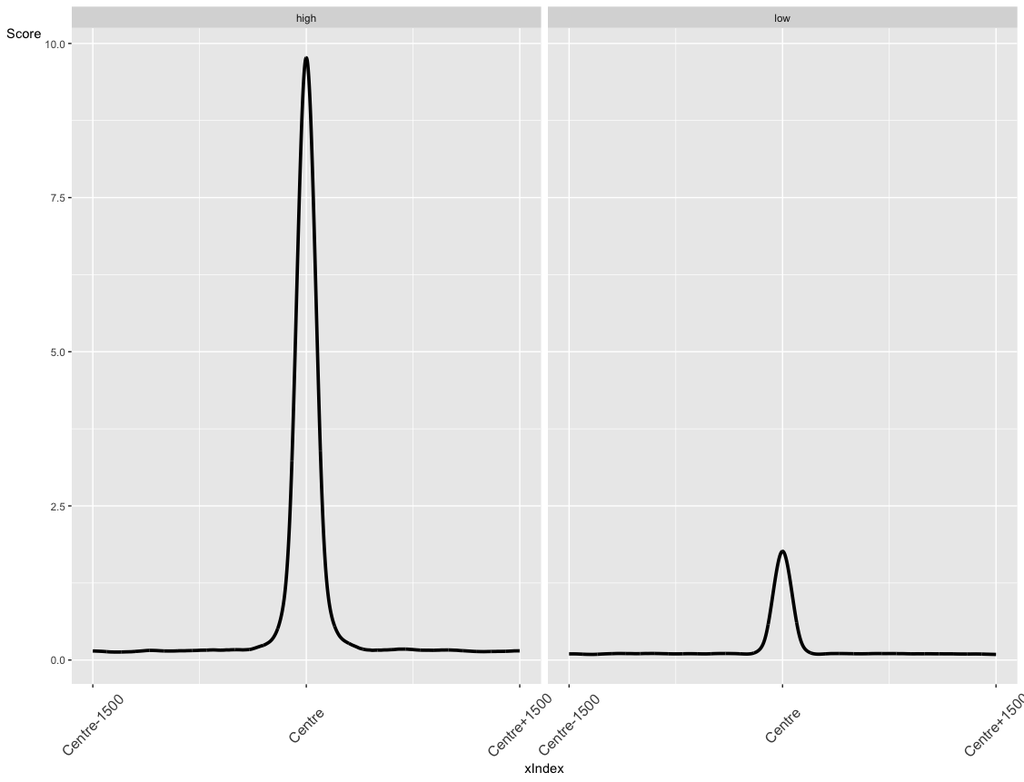

```r
rownames(CTCF_ch12) <- mcols(CTCF_ch12)$name
plotRegion(CTCF_ch12,
           gts=list(high=high,low=low))
```

# soGGi

We can also use lists of GRanges to group our data in soGGi.

```r
library(TxDb.Mmusculus.UCSC.mm10.knownGene)
dsds <- genes(TxDb.Mmusculus.UCSC.mm10.knownGene)
TSS <- resize(dsds,500,fix = "start")
TTS <- resize(dsds,500,fix = "end")
```

# soGGi

We can control colouring with the **colourBy** argument. Here we specify **Group** to colour by our newly defined groups.

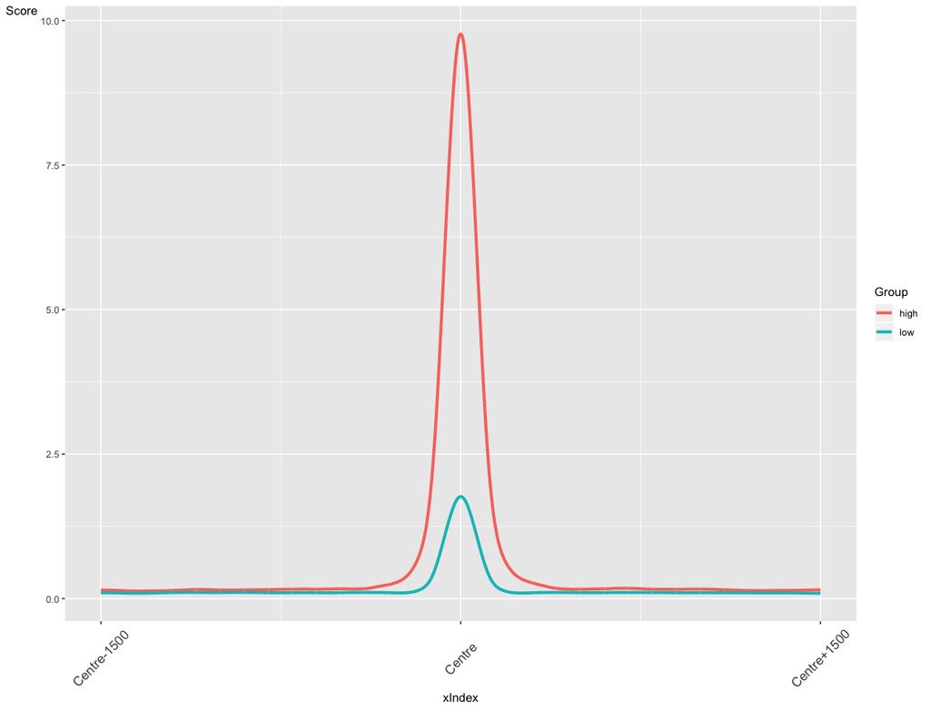

```r
plotRegion(CTCF_ch12,
           summariseBy = "Strength",
           colourBy = "Group")
```

# soGGi

Again we can use ggplot basics to add some of our own colour schemes to our plots.

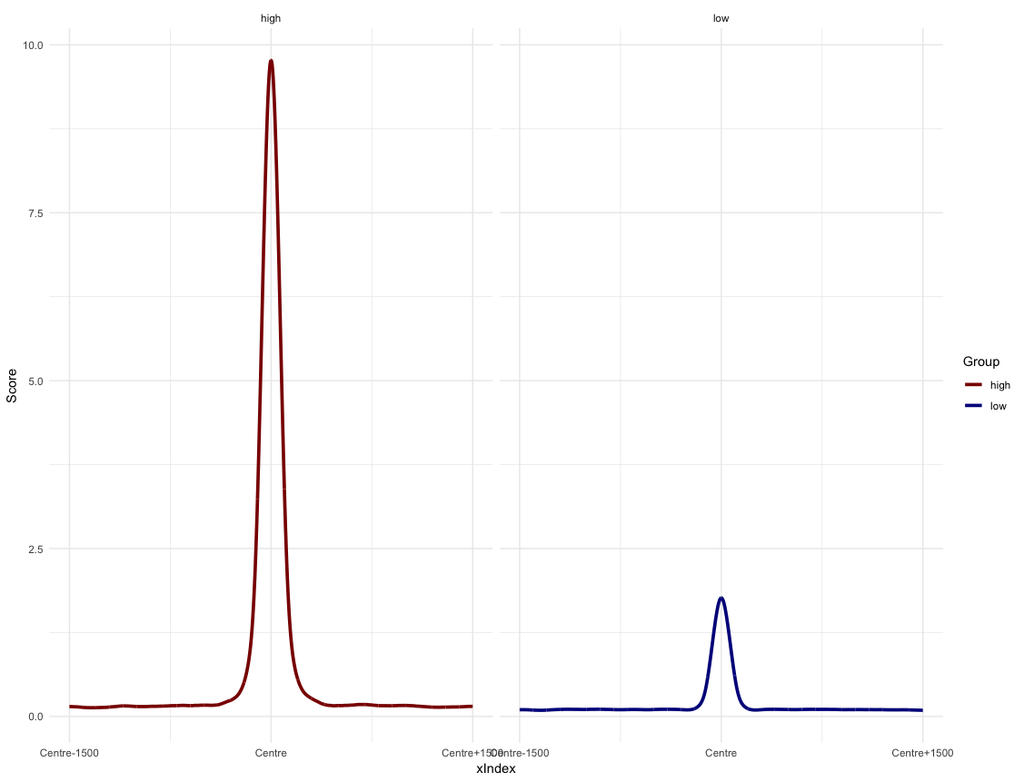

```r
p <- plotRegion(CTCF_ch12,
                 summariseBy = "Strength",
                 colourBy = "Group",
                 groupBy = "Group")
cols <- c("high" = "darkred", "low" = "darkblue")
p + scale_colour_manual(values = cols)+
  theme_minimal()
```

# soGGi

We can combine **ChIPprofile** objects just as with vectors and lists using the **c()** function.

```r
CTCF <- c(CTCF_mel,CTCF_ch12)
CTCF
```

```
## class: ChIPprofile
## dim: 61676 3001
## metadata(2): names AlignedReadsInBam
## assays(2): '' ''
## rownames(61676): giID2175 giID2176 ... giID59822 giID59823
## rowData names(10): baseMean log2FoldChange ... Strength giID
## colnames(3001): Point_Centre-1500 Point_Centre-1499 ...
##   Point_Centre1499 Point_Centre1500
## colData names(0):
```

# soGGi

We could also use the sample to facet our plot. Here we set **groupBy** to **Sample**.

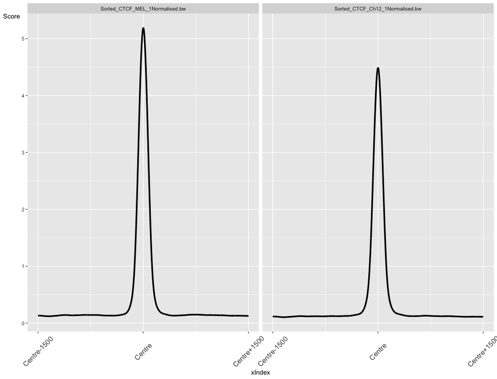

```r
plotRegion(CTCF,
           groupBy = "Sample")
```

# soGGi

We have previously used **soGGi** to produce our plots of footprints across motifs. Now we will use motif occurrence as the signal to plot instead of regions to plot over.

First we extract the CTCF motif and plot the seqLogo.

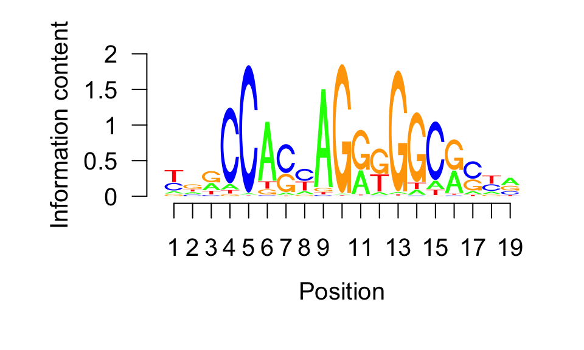

```r
library(MotifDb)
library(Biostrings)
library(seqLogo)
library(BSgenome.Mmusculus.UCSC.mm10)

CTCFm <- query(MotifDb, c("CTCF"))
ctcfMotif <- CTCFm[[1]]
seqLogo(ctcfMotif)
```

# soGGi

We can now plot our profile of motif occurrence across CTCF sites using the **regionPlot()** function and setting format parameter to **rlelist**.

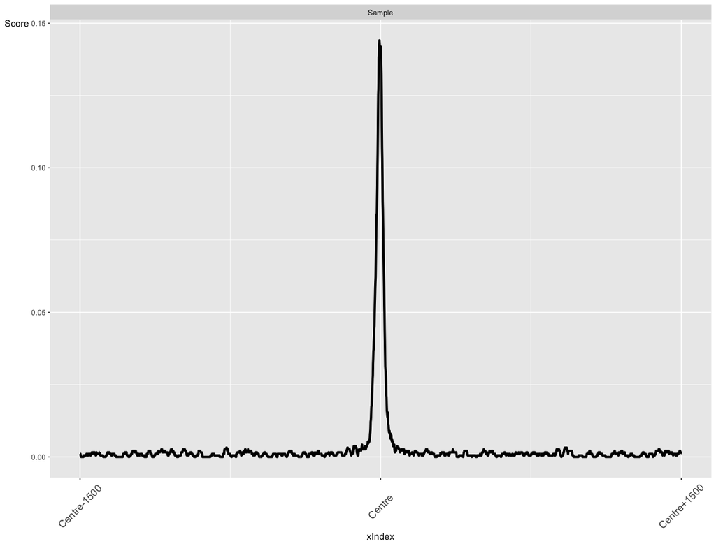

```r
motifPlot <- regionPlot(CTCFrle,
               CTCF_Ch12MinusMel,
               format = "rlelist")
plotRegion(motifPlot)
```

# soGGi

Since these two objects represent different data types, they will be in different scales.

We can set the scales to resize within our facets by setting **freeScale** parameter to TRUE.

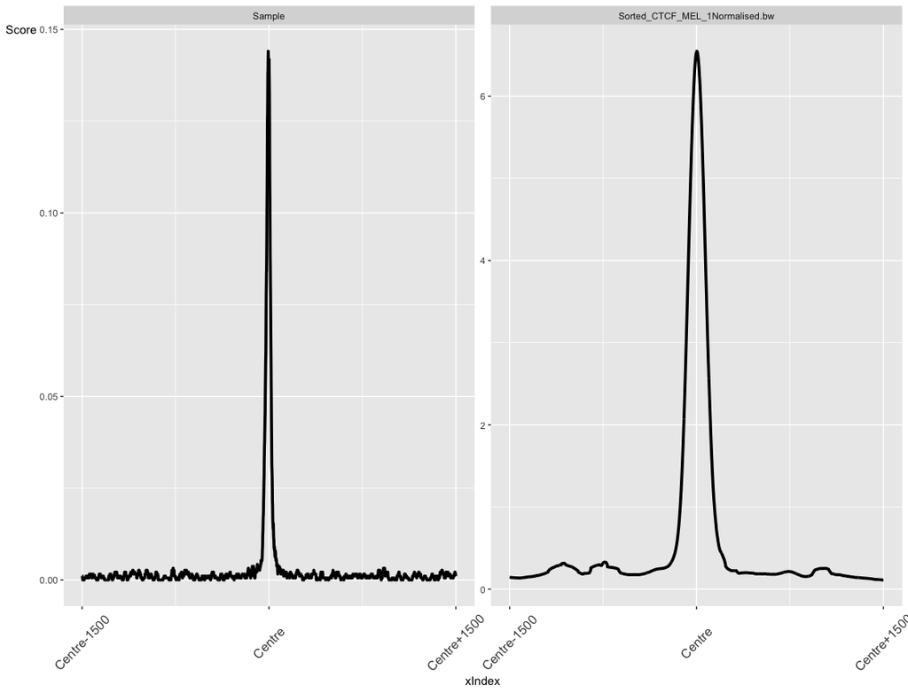

```r
p <- plotRegion(CTCFall,freeScale=TRUE)
p
```

# soGGi

To produce average plots over genes we must rescale genes to be the same size.This is performed by splitting genes into equal number of bins, with bin size variable across genes and plotting as percent of regions.

We can produce these plots in soGGi by setting **style** to **percentOfRegion**.

```r
pol2Ser2 <- regionPlot(bamFile = "~/Downloads/ENCFF239XXP.bigWig",
                    testRanges = dsds,style = "percentOfRegion",
                    format = "bigwig")
```

# soGGi

```r
CTCF_gene <- regionPlot(CTCFbigWig,
                    testRanges = dsds,
                    style = "percentOfRegion",
                    format = "bigwig")
```

# soGGi

We may also want to review our CTCF profile data as heatmap of signal across our sites.

We can produce heatmaps in soGGi using the **plotHeatmap** function. First we can extract a subset of sites to plot, here our sites which are higher in Mel.

Since ChIPprofile objects act like GRanges we can subset by our metadata columns using mcols() function.

```r
CTCF_Mel_Up <- CTCF[mcols(CTCF)$name %in% UpInMel,]
```

# soGGi

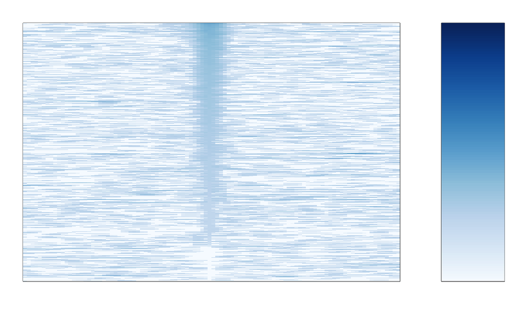

```r
k2 <- plotHeatmap(CTCF_Mel_Up[[2]],
                  col = colorRampPalette(blues9)(100),
                  maxValue=15)
```

## Solutions

Time for solutions! Link here